# Homework II - Bayesian Modelling (Yield of Potatoes)

Odysseas Kyparissis

22/Oct/2023

# Solution

## Inspection of available data

```r
###### data
# x is fertilizer levels
x <- c(1, 1.5, 2, 2.5, 3, 3.5, 4, 4.5)
# y is the yield of potatoes
y <- c(25, 31, 27, 28, 36, 35, NA, 34)
n <- length(y)
n
```

```
## [1] 8
```

```r
x
```

```
## [1] 1.0 1.5 2.0 2.5 3.0 3.5 4.0 4.5
```

```r
y
```

```
## [1] 25 31 27 28 36 35 NA 34
```

To begin with, the observed data are transformed into a data frame for easier manipulation. As it can be seen above, for the value of $fertilizer\_level (x) = 4.0$ there is a missing value for the yielding of potatoes $(y)$. For that reason, we exclude this row from the data, to perform the estimation of the requested distributions.

```r
# Create a data frame
df <- data.frame(x, y)

# Set column names for 'x' and 'y'
names(df) <- c("fertilizer_level", "potatoes_yield")

# Remove rows with NA values
df.noNA <- df[complete.cases(df), ]
row.names(df.noNA) <- NULL


# Display the resulting data frame with column names
print(df.noNA)
```

```
##   fertilizer_level potatoes_yield
## 1              1.0             25
## 2              1.5             31
## 3              2.0             27
## 4              2.5             28
## 5              3.0             36
## 6              3.5             35
## 7              4.5             34
```

To inspect the available data, a histogram for both the target and explanatory variables are presented below, just to get an overview of the distribution of the information we have available. Although, the histograms is presented in frequencies.

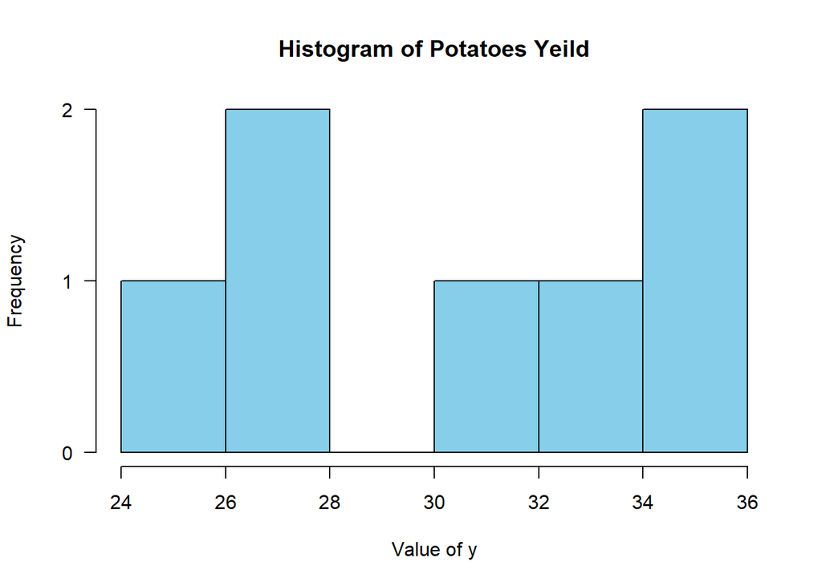

```r
hist(df.noNA$potatoes_yield,
     col = "skyblue",        # Fill color
     border = "black",       # Border color
     main = "Histogram of Potatoes Yeild", # Main title
     xlab = "Value of y",    # X-axis label
     ylab = "Frequency",     # Y-axis label
     probability = FALSE,    # Normalize to probability density
     las = 1                 # Make labels horizontal
)
```

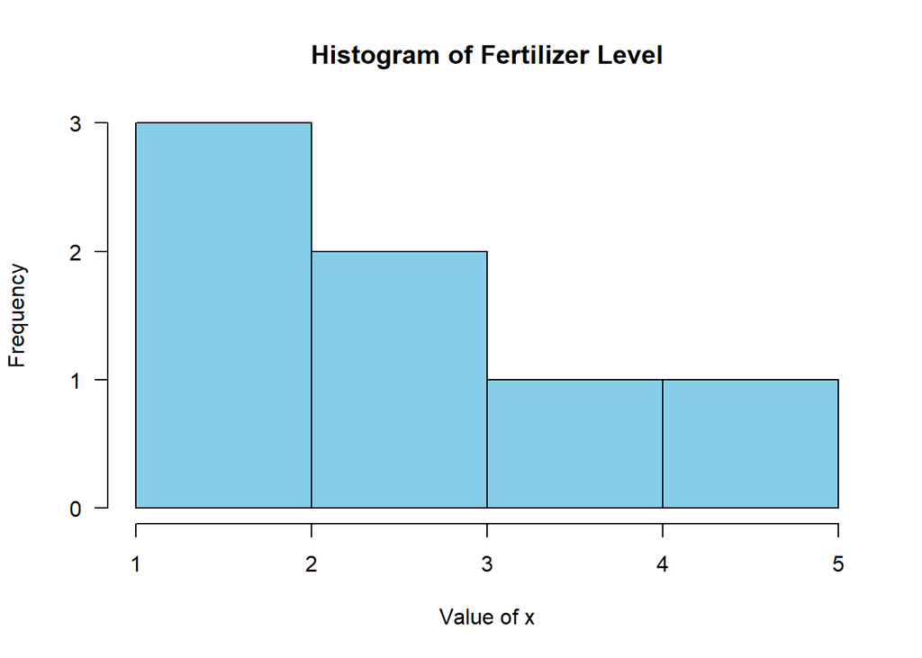

```r
hist(df.noNA$fertilizer_level,
     col = "skyblue",        # Fill color
     border = "black",       # Border color
     main = "Histogram of Fertilizer Level", # Main title
     xlab = "Value of x",    # X-axis label
     ylab = "Frequency",     # Y-axis label         # Y-axis limits
     probability = FALSE,     # Normalize to probability density
     las = 1                  # Make labels horizontal
)
```

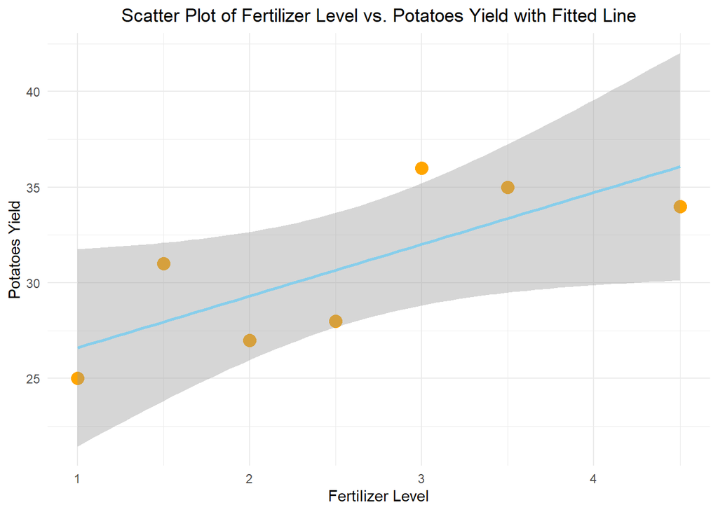

```r
# Create a scatter plot with a fitted line
plot <- ggplot(df.noNA, aes(x = fertilizer_level, y = potatoes_yield)) +
  geom_point(color = "orange", size = 4) +
  geom_smooth(method = "lm", formula = y ~ x, color = "skyblue", se = TRUE) + # Add a linear regression line
  labs(
    title = "Scatter Plot of Fertilizer Level vs. Potatoes Yield with Fitted Line",
    x = "Fertilizer Level",
    y = "Potatoes Yield"
  ) +
  theme_minimal() +
  theme(plot.title = element_text(hjust = 0.5))

# Display the scatter plot
print(plot)
```

From the visual result, it can be understood that some correlation between the two variables exist. Moreover, we can see that the variability of the potatoes yield increases when the fertilizer level increases. A linear regression, would have smaller variability for the potato yielding value for low levels of fertilizer level ($2\ to\ 3$), but as the values of fertilizer level gets higher the variability is bigger. However, even the difference in the variability levels of potatoes yield are not so significant.

Let’s take a look at the logarithmic scales of both variables.

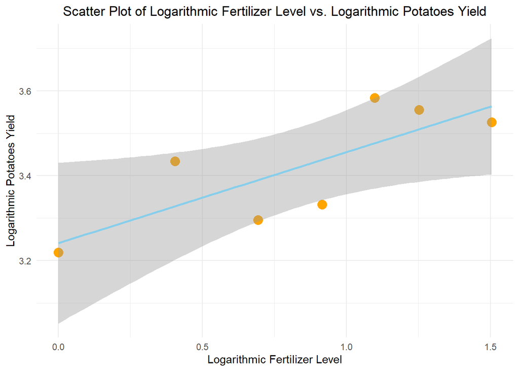

```r
# Create a scatter plot with logarithmic scales
# Take the logarithm of 'fertilizer_level' and 'potatoes_yield'
df.noNA$log_fertilizer_level <- log(df.noNA$fertilizer_level)
df.noNA$log_potatoes_yield <- log(df.noNA$potatoes_yield)

# Create a scatter plot with logarithmic scales
plot <- ggplot(df.noNA, aes(x = log_fertilizer_level, y = log_potatoes_yield)) +
  geom_point(color = "orange", size = 4) +
  geom_smooth(method = "lm", formula = y ~ x, color = "skyblue", se = TRUE) + # Add a linear regression line
  labs(
    title = "Scatter Plot of Logarithmic Fertilizer Level vs. Logarithmic Potatoes Yield",
    x = "Logarithmic Fertilizer Level",
    y = "Logarithmic Potatoes Yield"
  ) +
  theme_minimal() +
  theme(plot.title = element_text(hjust = 0.5))

# Display the scatter plot
print(plot)
```

There is not a big difference in the scatter plots between logarithmic and linear scales. For that reason, the solution of this exercise will continue by using the original values of the statement, and not the logarithmic ones.

Additionally, some basic statistics are calculated on the sample, to help the understandability of the methods performed in the next sections.

```r
# Drop logarithmic columns
df.noNA <- df.noNA[, c("fertilizer_level", "potatoes_yield")]
mean.x <- mean(df.noNA$fertilizer_level)
mean.y <- mean(df.noNA$potatoes_yield)
std.x <- sd(df.noNA$fertilizer_level)
std.y <- sd(df.noNA$potatoes_yield)
mean.x ; mean.y;
```

```
## [1] 2.571429
```

```
## [1] 30.85714
```

```r
std.x ; std.y
```

```
## [1] 1.205148
```

```
## [1] 4.298394
```

Also, we know that, the potatoes yield ($y$) given the fertilizer level ($x$) is: $p(y|x) \sim Normal( \beta_0 + \beta_ 1x, \sigma)$.

## (a) Using non-informative priors for the parameters draw the posterior distribution for all of them

It’s always good to have a look at the prior distributions in a graphical way before proceeding with the simulations.

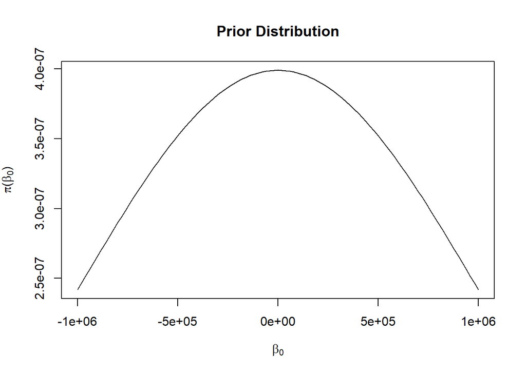

```r
plot(function(x)dnorm(x,0,1000000), xlim = c(-1000000,1000000), xlab=expression(beta[0]), main="Prior Distribution", ylab=expression(paste(pi,"(",beta[0],")")))
```

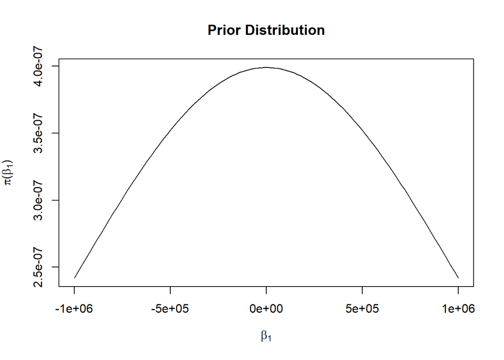

```r
plot(function(x)dnorm(x,0,1000000), xlim = c(-1000000,1000000), xlab=expression(beta[1]), main="Prior Distribution", ylab=expression(paste(pi,"(",beta[1],")")))
```

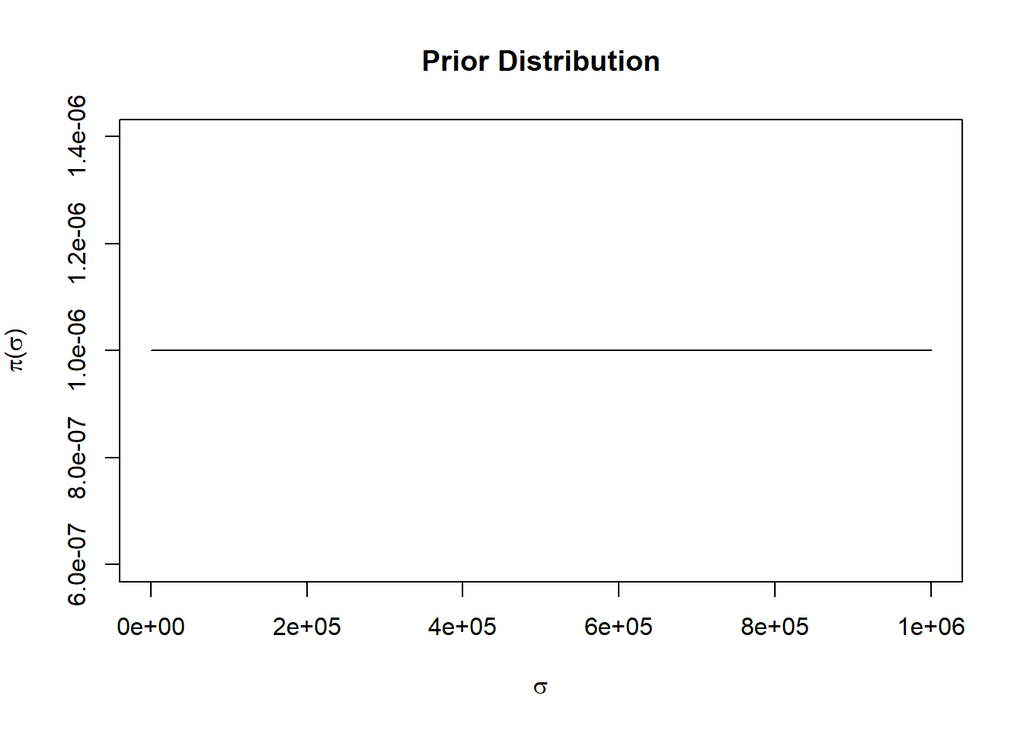

```r
plot(function(x)dunif(x,0,1000000), xlim = c(0,1000000), xlab=expression(sigma), main="Prior Distribution", ylab=expression(paste(pi,"(",sigma,")")))
```

All three graphs, represent the uncertainty we have about the three parameters of the Bayesian model. Both a Normal distribution with huge variance, or a uniform distribution with small $\alpha$ and huge $\beta$, can be used as non-informative priors. In that way, we are expressing a huge uncertainty about the intercept and the angle of the regression slope, as well as its variability. Meaning, we are describing the probability of the parameters to get a certain value to be equally distributed in a range of real numbers.

Now we can proceed with the definition of the Bayesian Model, with the help of JAGS. By performing formula transformations to bring the priors at the same level as the functions of JAGS are defined, the following model is produced. First of all, we are gonna ask from JAGS to simulate two Marcov Chains, of 3 Thins of 10000 iterations, and 1000 burning simulations. It is necessary to correctly define the distributions of the probability model, as well as the distributions of the priors.

```r
# parameters MCMC
Iter <- 10000
Burn <- 1000
Chain <- 2
Thin <- 3

regression <- "
model {
 for (i in 1:n) {
  y[i] ~ dnorm(b0+b1*x[i], tau)
 }
 # prior distributions
 b0 ~ dnorm(0, 1.0e-7)
 b1 ~ dnorm(0, 1.0e-7)
 sigma ~ dunif(0, 100000)
 tau <- pow(sigma, -2)

}
"
```

Once everything is defined, we need to provide the observed data and some initialization values for the 3 parameters to JAGS in order to begin the simulations.

```r
# data is set to include the x and y values of the experiment
data <- list(n = nrow(df.noNA),
             y = df.noNA$potatoes_yield, x = df.noNA$fertilizer_level)

# initials contain two different sets of initialization values for the parameters
# one for each chain
initials <- list(list(b0=0, b1=0, sigma=1),list(b0=10, b1=10, sigma=3.16))

# explicitly state the parameters of the model used with JAGS
parameters <- c("b0", "b1", "sigma")

model.potatoes <- jags(data, initials, parameters.to.save=parameters,
              model=textConnection(regression),
            n.iter=(Iter*Thin+Burn),n.burnin=Burn, n.thin=Thin, n.chains=Chain)
```

```
## module glm loaded
```

Once the simulation is done, we can take a look at the summary of JAGS for the specific model.

```r
print(model.potatoes)
```

```
## Inference for Bugs model at "4", fit using jags,
##  2 chains, each with 31000 iterations (first 1000 discarded), n.thin = 3
##  n.sims = 20000 iterations saved
##          mu.vect sd.vect   2.5%    25%    50%    75%  97.5%  Rhat n.eff
## b0        23.927   4.662 14.711 21.492 23.927 26.368 33.142 1.006  4100
## b1         2.695   1.654 -0.560  1.836  2.692  3.545  6.003 1.005  2800
## sigma      4.327   2.219  2.056  2.968  3.767  4.976 10.057 1.002  1400
## deviance  38.071   3.967 33.564 35.168 37.054 39.911 48.384 1.003  1800
##
## For each parameter, n.eff is a crude measure of effective sample size,
## and Rhat is the potential scale reduction factor (at convergence, Rhat=1).
##
## DIC info (using the rule, pD = var(deviance)/2)
## pD = 7.9 and DIC = 45.9
## DIC is an estimate of expected predictive error (lower deviance is better).
```

From the summary, one can find point estimates of the parameters, as well as their percentiles. Before proceeding with the plotting of the posterior distributions of the parameters, it is necessary to check if the MCMC algorithm converged apropprietly to its stationary distribution for each parameter, which is a good approximation of their posterior distribution.

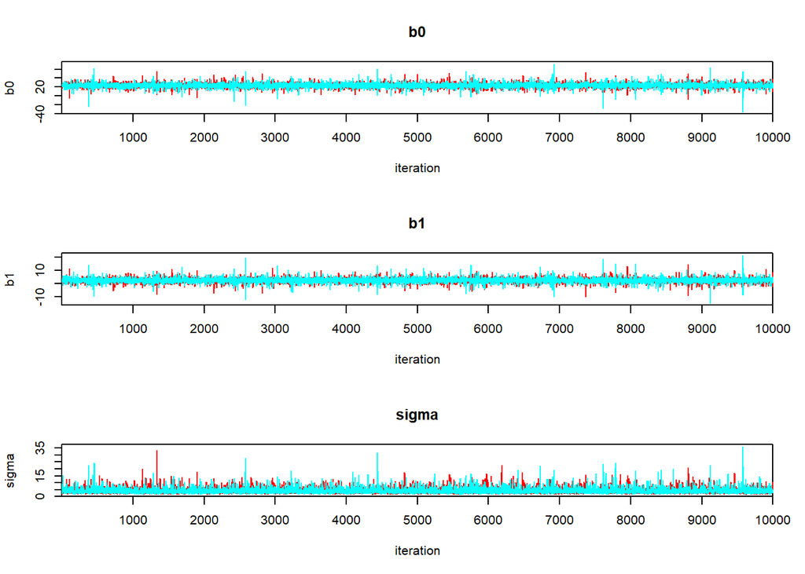

```r
traceplot(model.potatoes, mfrow = c(length(parameters),1), varname = parameters)
```

From the traceplot, one can understand that the convergence of the MCMC algorithm has been accomplished.

In the following plot, the 3 first graphs present the posterior distribution of each parameter, together with their 95% CI. The final graph presents the regression line that describes the mean value of the Normal distribution, which is the function that the yielding of potatoes is following.

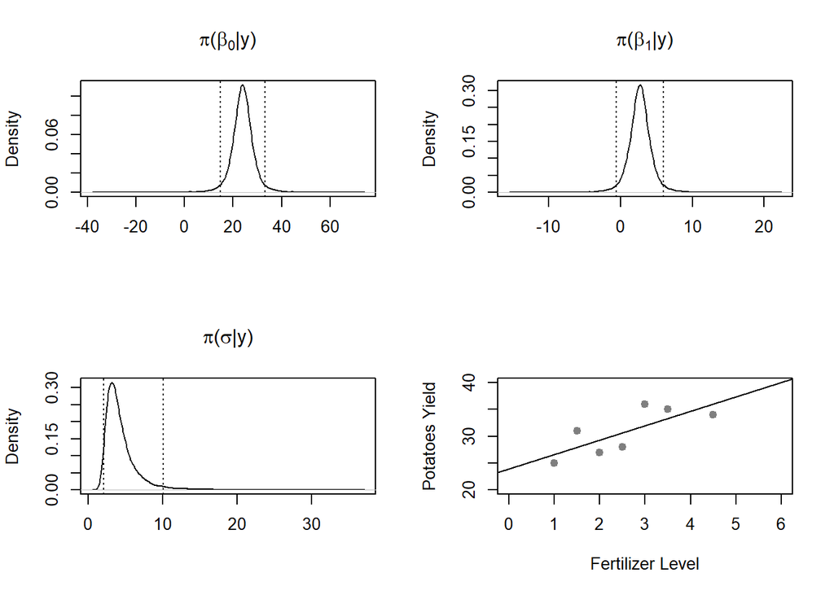

```r
attach.jags(model.potatoes)

  par(mfrow=c(2,2))

    plot(density(b0, adjust = 1.5), main = expression(paste(pi,"(",beta[0],"|y)")), xlab= "" ); abline(v=quantile(b0,c(0.025,0.975)),lty=3)
    plot(density(b1, adjust = 1.5), main = expression(paste(pi,"(",beta[1],"|y)")), xlab= ""  ); abline(v=quantile(b1,c(0.025,0.975)),lty=3)
    plot(density(sigma, adjust = 1.5), main = expression(paste(pi,"(",sigma,"|y)")), xlab= "" ); abline(v=quantile(sigma,c(0.025,0.975)),lty=3)

  plot(c(0,6), c(20,40), type = "n", xlab = "Fertilizer Level",
       ylab ="Potatoes Yield" )
  points(data$x, data$y, pch=19, col="gray50")
  abline(coef=c(mean(b0),mean(b1)))
```

```r
detach.jags()
```

## (b) Calculate a 95% credible interval for each parameter.

To be more precise and present the numbers of the 95% CI of the parameters, the following procedure is performed.

```r
attach.jags(model.potatoes)

# Compute credible intervals for b0, b1, and sigma
b0.CI <- quantile(b0, c(0.025, 0.975))
b1.CI <- quantile(b1, c(0.025, 0.975))
sigma.CI <- quantile(sigma, c(0.025, 0.975))

# Display credible intervals for the intercept (b0), slope (b1), and standard deviation (sigma) parameters.
cat("95% Credible Interval for Intercept (b0): ", b0.CI[1], " to ", b0.CI[2], "\n")
```

```
## 95% Credible Interval for Intercept (b0):  14.7106  to  33.14183
```

```r
cat("95% Credible Interval for Slope (b1): ", b1.CI[1], " to ", b1.CI[2], "\n")
```

```
## 95% Credible Interval for Slope (b1):  -0.5597997  to  6.003079
```

```r
cat("95% Credible Interval for Standard Deviation (sigma): ", sigma.CI[1], " to ", sigma.CI[2], "\n")
```

```
## 95% Credible Interval for Standard Deviation (sigma):  2.056386  to  10.05695
```

```r
detach.jags()
```

## (c) Calculate a 95% credible interval for y given x = 4.

In this section, the prediction of a 95% probability interval of the potato yielding ($y$) given a fertilizer level $x=4$ is taking place. To perform this analysis, it is necessary to simulate $M$ values from the predictive posterior distribution. As the the number of the simulations increases, the approximation of the prediction is closer to the real one. In this approach, $M$ is being set equal to $10Mil$. The same number of iterations kept from the markov chains, after they converged to their stationary distribution, could also be used as M, but in order to get more precise results a way bigger number ($10Mil$) was selected. By providing the results of the JAGS simulations to the function `rnorm`, 10 milion simulations of the posterior predictive distribution, specifically for $x$ being equal to 4 will be returned. In the following figure we can have a look at the density estimation of the returned vector.

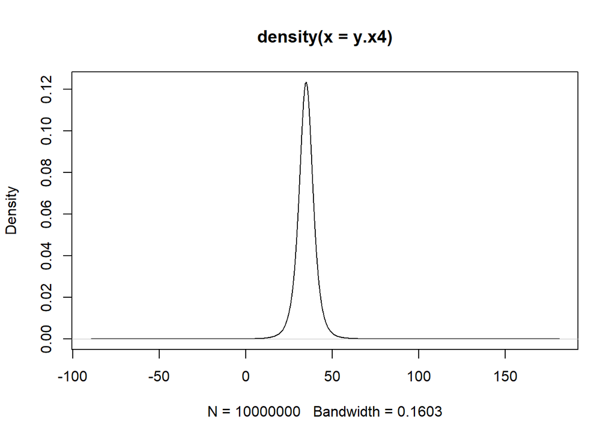

```r
# prediction of probability interval of the potato yielding given a fertilizer level equal to 4.0.
attach.jags(model.potatoes)
M <- 10000000

# Simulation of the potato yielding given a fertilizer level equal to 4.0.
y.x4 <- rnorm(M, b0+b1*4, sigma)
#y.x4

plot(density(y.x4))
```

```r
detach.jags()
```

Finally, in order to provide a 95% CI for the yielding potatoes when the fertilizer level is equal to 4, the following operations are conducted.

```r
cat("Summary of y.x4:\n")
```

```
## Summary of y.x4:
```

```r
print(summary(y.x4))
```

```
##    Min. 1st Qu.  Median    Mean 3rd Qu.    Max.
##  -89.29   31.71   34.71   34.71   37.71  180.70
```

```r
cat("\n95% Confidence Interval (2.5th and 97.5th percentiles):\n")
```

```
##
## 95% Confidence Interval (2.5th and 97.5th percentiles):
```

```r
print(quantile(y.x4, c(0.025, 0.975)))
```

```
##     2.5%    97.5%
## 23.42923 45.93152
```